# Model training and Evaluation

In this notebook, after data processing and feature evaluation and selection, we are finally about to train the model !! Yay 😄

training a XGBoost model on the dataset, which is able to attain private and public scores of **0.856** respectively.

```python
# Main tools we used:
import numpy as np # linear algebra
import pandas as pd # data processing, CSV file I/O (e.g. pd.read_csv)

# Models:
from sklearn import svm
from sklearn.model_selection import cross_validate
from sklearn.linear_model import LinearRegression
from sklearn.ensemble import RandomForestClassifier

from sklearn.metrics import accuracy_score, precision_score, recall_score, f1_score, roc_auc_score, roc_curve
from sklearn.metrics import classification_report, accuracy_score
from sklearn.model_selection import train_test_split
from sklearn.model_selection import cross_val_score
from sklearn.metrics import roc_auc_score, confusion_matrix, auc
from sklearn import model_selection

from sklearn.model_selection import GridSearchCV, StratifiedKFold, KFold
from sklearn.ensemble import RandomForestClassifier, VotingClassifier
from sklearn.linear_model import LogisticRegression
from sklearn.neighbors import KNeighborsClassifier

from sklearn.svm import SVC
import xgboost as xgb
from xgboost import XGBClassifier
import lightgbm as lgb
import joblib

# plot utilities:
import seaborn as sns
import matplotlib.pyplot as plt
%matplotlib inline

# Python utilities:
import time
import os
```

```python
# Import Data from processed csv that we created from pre-processing step
df_train_processed = pd.read_csv("csv/processed_data_train.csv")
df_test_processed = pd.read_csv("csv/processed_data_test.csv")

df_test= pd.read_csv("csv/cs-test.csv")
df_train = pd.read_csv("csv/cs-training.csv")
df_oversampled =pd.read_csv("csv/oversampled_data.csv")

print("df_train_processed shape:", df_train_processed.shape)
print("df_test shape:", df_test.shape)
print("df_oversampled shape:", df_oversampled.shape)
```

```
df_train_processed shape: (146021, 11)
df_test shape: (101503, 12)
df_oversampled shape: (272504, 12)
```

```python
df_train_created = pd.read_csv("df_train_created.csv")
df_train_created
```

|  | SeriousDlqin2yrs | RevolvingUtilizationOfUnsecuredLines | age | DebtRatio | MonthlyIncome | NumberOfOpenCreditLinesAndLoans | NumberRealEstateLoansOrLines | NumberOfDependents | TotalPastDue |
| --- | --- | --- | --- | --- | --- | --- | --- | --- | --- |
| 0 | 1 | 0.766127 | 45 | 0.802982 | 9120.0 | 13 | 6 | 2.0 | 2 |
| 1 | 0 | 0.957151 | 40 | 0.121876 | 2600.0 | 4 | 0 | 1.0 | 0 |
| 2 | 0 | 0.658180 | 38 | 0.085113 | 3042.0 | 2 | 0 | 0.0 | 2 |
| 3 | 0 | 0.233810 | 30 | 0.036050 | 3300.0 | 5 | 0 | 0.0 | 0 |
| 4 | 0 | 0.907239 | 49 | 0.024926 | 63588.0 | 7 | 1 | 0.0 | 1 |
| ... | ... | ... | ... | ... | ... | ... | ... | ... | ... |
| 146016 | 0 | 0.385742 | 50 | 0.404293 | 3400.0 | 7 | 0 | 0.0 | 0 |
| 146017 | 0 | 0.040674 | 74 | 0.225131 | 2100.0 | 4 | 1 | 0.0 | 0 |
| 146018 | 0 | 0.299745 | 44 | 0.716562 | 5584.0 | 4 | 1 | 2.0 | 0 |
| 146019 | 0 | 0.000000 | 30 | 0.000000 | 5716.0 | 4 | 0 | 0.0 | 0 |
| 146020 | 0 | 0.850283 | 64 | 0.249908 | 8158.0 | 8 | 2 | 0.0 | 0 |

146021 rows × 9 columns

```python
df_test_id =df_test["Unnamed: 0"]
df_train = df_train.drop(["Unnamed: 0"],axis=1)
df_test = df_test.drop(["Unnamed: 0"],axis=1)

print("df_test shape:", df_test.shape)
print("df_train shape:", df_train.shape)
```

```
df_test shape: (101503, 11)
df_train shape: (150000, 11)
```

```python
missing_values = df_train_processed.isna().sum()
missing_values
```

```
SeriousDlqin2yrs                        0
RevolvingUtilizationOfUnsecuredLines    0
age                                     0
NumberOfTime30-59DaysPastDueNotWorse    0
DebtRatio                               0
MonthlyIncome                           0
NumberOfOpenCreditLinesAndLoans         0
NumberOfTimes90DaysLate                 0
NumberRealEstateLoansOrLines            0
NumberOfTime60-89DaysPastDueNotWorse    0
NumberOfDependents                      0
dtype: int64
```

```python
missing_values = df_test_processed.isna().sum()
missing_values
```

```
SeriousDlqin2yrs                        101503
RevolvingUtilizationOfUnsecuredLines         0
age                                          0
NumberOfTime30-59DaysPastDueNotWorse         0
DebtRatio                                    0
MonthlyIncome                                0
NumberOfOpenCreditLinesAndLoans              0
NumberOfTimes90DaysLate                      0
NumberRealEstateLoansOrLines                 0
NumberOfTime60-89DaysPastDueNotWorse         0
NumberOfDependents                           0
dtype: int64
```

```python
## plot roc curve function
def plot_roc(y_test,prob):
    fpr, tpr, thresholds = roc_curve(y_test, prob)
    # plot no skill
    plt.plot([0, 1], [0, 1], linestyle='--')
    # plot the roc curve for the model
    plt.plot(fpr, tpr, marker='.')
    plt.title("ROC curve")
    plt.xlabel('false positive rate')
    plt.ylabel('true positive rate')
    # show the plot
    plt.show()
```

```python
def evaluate_model(model, X_train, Y_train, val_x, val_y):
    # Extract the model name from the model object
    model_name = type(model).__name__

    if '-' in model_name:
        model_name = model_name.split('-')[1]

    # Calculate the accuracy score on the training set
    accuracy_train = accuracy_score(Y_train, model.predict(X_train))
    print("Accuracy on training set:", accuracy_train)

    # Calculate the ROC AUC score on the training set
    roc_auc_train = roc_auc_score(Y_train, model.predict_proba(X_train)[:, 1])
    print("ROC AUC score on training set:", roc_auc_train)

    # Calculate the accuracy score on the validation set
    accuracy_val = accuracy_score(val_y, model.predict(val_x))
    print("Accuracy on validation set:", accuracy_val)

    # Calculate the ROC AUC score on the validation set
    roc_auc_val = roc_auc_score(val_y, model.predict_proba(val_x)[:, 1])
    print("ROC AUC score on validation set:", roc_auc_val)

    # Compute the false positive rate, true positive rate, and thresholds for training set
    fpr_train, tpr_train, thresholds_train = roc_curve(Y_train, model.predict_proba(X_train)[:, 1])

    # Compute the false positive rate, true positive rate, and thresholds for validation set
    fpr_val, tpr_val, thresholds_val = roc_curve(val_y, model.predict_proba(val_x)[:, 1])

    # Plot the ROC curves
    plt.plot(fpr_train, tpr_train, label='Training')
    plt.plot(fpr_val, tpr_val, label='Validation')
    plt.plot([0, 1], [0, 1], linestyle='--', label='Default')
    plt.xlabel('False Positive Rate')
    plt.ylabel('True Positive Rate')
    plt.title('ROC Curve ({})'.format(model_name))
    plt.legend()
    plt.show()
```

```python
def display_evaluation_metrics(model, val_x, val_y):
    """
    Calculates and displays the evaluation metrics for a classification model.

    Parameters:
    - model: Trained classification model
    - val_x: Validation set features
    - val_y: Validation set target variable

    Prints a table showing the evaluation metrics: Accuracy, Precision, Recall, F1-score, AUC-ROC, and Gini coefficient.
    """

    # Make predictions on the validation set
    y_pred = model.predict(val_x)

    # Calculate accuracy
    accuracy = accuracy_score(val_y, y_pred)

    # Calculate precision
    precision = precision_score(val_y, y_pred)

    # Calculate recall
    recall = recall_score(val_y, y_pred)

    # Calculate F1-score
    f1 = f1_score(val_y, y_pred)

    # Calculate predicted probabilities for positive class
    y_pred_prob = model.predict_proba(val_x)[:, 1]

    # Calculate AUC-ROC
    auc_roc = roc_auc_score(val_y, y_pred_prob)

    # Calculate Gini coefficient
    gini = 2 * auc_roc - 1

    # Create a list of metric names and values
    metric_names = ['Accuracy', 'Precision', 'Recall', 'F1-score', 'AUC-ROC', 'Gini coefficient']
    metric_values = [accuracy, precision, recall, f1, auc_roc, gini]

    # Create a list of metric rows
    metric_rows = [[name, value] for name, value in zip(metric_names, metric_values)]

    # Print the table for evaluation metrics
    print(tabulate(metric_rows, headers=['Metric', 'Value'], tablefmt='orgtbl'))
```

```python
def split_data(X_train, Y_train, test_size=0.3, random_state=2020):
    """
    Split the data into training and validation sets.

    Parameters:
    - X_train: The features (input variables) for training.
    - Y_train: The target variable for training.
    - test_size: The proportion of the data to include in the validation set. Default is 0.3.
    - random_state: The random state for reproducibility. Default is 2020.

    Returns:
    - X_train: The training features.
    - val_x: The validation features.
    - Y_train: The training target variable.
    - val_y: The validation target variable.
    """
    X_train, val_x, Y_train, val_y = train_test_split(
        X_train, Y_train, test_size=test_size, random_state=random_state)

    return X_train, val_x, Y_train, val_y
```

```python
#ROC dict for TPR and FPR values
roc_dict = {}
#precision recall curve
prc_dict = {}

###
# FPR: False Positive Rate
# TPR: True Positive Rate, also known as Sensitivity, Recall, or Hit Rate
###
def modify_roc_dict(clf, y_test, X_test, name ,dict_modify):
    """
    modifies a dictionary in place and adds keys for ROC metrics
    """

    fpr, tpr, thresholds = roc_curve(y_test,
                                     clf.predict_proba(X_test)[:,1],
                                     pos_label=1)


    clf_roc_dict = {'fpr':fpr, 'tpr': tpr, 'thresholds': thresholds}

    dict_modify[name] = clf_roc_dict

def modify_prc_dict(clf, y_test, X_test, name ,dict_modify):
    """
    modifies a dictionary in place and adds keys for precision recall metrics
    """

    precision, recall, thresholds = precision_recall_curve(y_test,
                                     clf.predict_proba(X_test)[:,1],
                                     pos_label=1)

    clf_prc_dict = {'precision':precision, 'recall': recall, 'thresholds': thresholds}

    dict_modify[name] = clf_prc_dict
```

## xgboost

```python
from xgboost import XGBClassifier
from sklearn.metrics import accuracy_score
from sklearn.metrics import confusion_matrix, classification_report
```

Firstly train xgboost model using raw data before any process

```
Accuracy on training set: 0.9497904761904762
ROC AUC score on training set: 0.9190486371809523
Accuracy on validation set: 0.9354888888888889
ROC AUC score on validation set: 0.8584350946562426
```

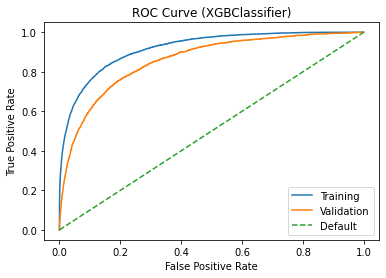

```python
## train xgboost model using raw data before any process
y_train=df_train['SeriousDlqin2yrs'].astype('uint8')
X_train, val_x, Y_train, val_y = split_data(df_train.drop('SeriousDlqin2yrs', axis=1), y_train)

model_xgboost= XGBClassifier()
model_xgboost.fit(X_train,Y_train.values.ravel())

Y_pred = model_xgboost.predict(X_train)
evaluate_model(model_xgboost, X_train, Y_train, val_x, val_y)
```

```python
print(classification_report(Y_train,Y_pred))
```

```
              precision    recall  f1-score   support

           0       0.95      1.00      0.97     98005
           1       0.83      0.32      0.46      6995

    accuracy                           0.95    105000
   macro avg       0.89      0.66      0.72    105000
weighted avg       0.95      0.95      0.94    105000
```

```python
display_evaluation_metrics(model_xgboost, val_x, val_y)
```

```
| Metric           |    Value |
|------------------+----------|
| Accuracy         | 0.935733 |
| Precision        | 0.566127 |
| Recall           | 0.196305 |
| F1-score         | 0.291524 |
| AUC-ROC          | 0.859349 |
| Gini coefficient | 0.718699 |
```

```
Accuracy on training set: 0.8953667589330649
ROC AUC score on training set: 0.9650236201395733
Accuracy on validation set: 0.8820456991877874
ROC AUC score on validation set: 0.9563855219512047
```

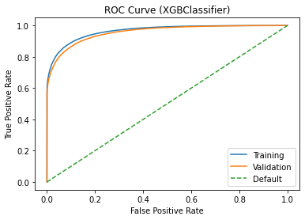

```python
#  train xgboost model using df_train_processed

##X_train, val_x, Y_train, val_y = split_data(df_train_processed.drop('SeriousDlqin2yrs', axis=1), df_train_processed['SeriousDlqin2yrs'])

###################### replace dataset with df_train_created or df_oversampled
# Split the data into training and validation sets using df_train_created
#X_train, val_x, Y_train, val_y = split_data(df_train_created.drop('SeriousDlqin2yrs', axis=1), df_train_created['SeriousDlqin2yrs'])
X_train, val_x, Y_train, val_y = split_data(df_oversampled.drop('SeriousDlqin2yrs', axis=1), df_oversampled['SeriousDlqin2yrs'])
#####################

# Initialize and fit the XGBoost model
model_xgboost = xgb.XGBClassifier()
model_xgboost.fit(X_train, Y_train)

Y_pred = model_xgboost.predict(X_train)
evaluate_model(model_xgboost, X_train, Y_train, val_x, val_y)### On the created data with combined columns
```

```python
display_evaluation_metrics(model_xgboost, val_x, val_y)
```

```
| Metric           |    Value |
|------------------+----------|
| Accuracy         | 0.882046 |
| Precision        | 0.899821 |
| Recall           | 0.860186 |
| F1-score         | 0.879557 |
| AUC-ROC          | 0.956386 |
| Gini coefficient | 0.912771 |
```

```python
#metrics for xgboost
modify_roc_dict(clf=model_xgboost,
                y_test=val_y,
                X_test=val_x,
                name='XGBoost',
                dict_modify=roc_dict)
modify_prc_dict(clf=model_xgboost,
                y_test=val_y,
                X_test=val_x,
                name='XGBoost',
                dict_modify=prc_dict)
```

```python
cm = confusion_matrix(Y_train,Y_pred)
```

[figure not shown]

```python
sns.heatmap(cm,annot=True,fmt='d',cmap='Oranges',linewidths=0.5,linecolor='Black')
plt.xticks(np.arange(2)+.5,['No def','def'])
plt.yticks(np.arange(2)+.5,['No def','def'])
plt.xlabel("predicted")
plt.ylabel("actuals")
```

```python
print(classification_report(Y_train,Y_pred))
```

```
              precision    recall  f1-score   support

           0       0.88      0.92      0.90     95433
           1       0.91      0.88      0.89     95319

    accuracy                           0.90    190752
   macro avg       0.90      0.90      0.90    190752
weighted avg       0.90      0.90      0.90    190752
```

### Using oversampled dataframe

```
Accuracy on training set: 0.9147322177486998
ROC AUC score on training set: 0.975677497965604
Accuracy on validation set: 0.8926142479694686
ROC AUC score on validation set: 0.962450260927302
```

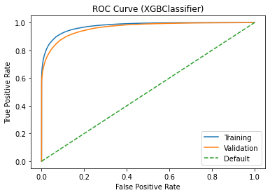

```python
# Convert the target variable to 'uint8'
# Since the target variable contains binary values (0 or 1), it can be efficiently represented using the 'uint8' data type
y_train_oversampled = df_oversampled['SeriousDlqin2yrs'].astype('uint8')

# Split the data into training and validation sets
X_train_oversampled, val_x_oversampled, Y_train_oversampled, val_y_oversampled = split_data(df_oversampled.drop('SeriousDlqin2yrs', axis=1), y_train_oversampled)


# Initialize the XGBoost classifier
model_oversampledXGB = XGBClassifier(tree_method='exact', n_jobs=-1, n_estimators=220)

# Train the model on the oversampled training set
model_oversampledXGB.fit(X_train_oversampled, Y_train_oversampled)

# Predict on the oversampled training set
y_pred_oversampled = model_oversampledXGB.predict(X_train_oversampled)

evaluate_model(model_oversampledXGB, X_train_oversampled, Y_train_oversampled, val_x_oversampled, val_y_oversampled)
```

```python
roc_auc_train = roc_auc_score(Y_train_oversampled, model_oversampledXGB.predict_proba(X_train_oversampled)[:, 1])
roc_auc_train
```

```
0.975677497965604
```

The ROC AUC score is a metric that measures the performance of a classification model in terms of its ability to distinguish between positive and negative classes. A higher ROC AUC score indicates better model performance.

The significant increase in the ROC AUC score implies that the oversampling technique (SMOTE) has effectively addressed the class imbalance issue and improved the model's performance. It has provided the model with more information and examples of the minority class, allowing it to learn better decision boundaries and make more accurate predictions.

Therefore, the interpretation is that the oversampled model is **more robust and reliable in classifying instances, particularly in correctly identifying positive instances (the minority class) compared to the model trained on the original data.**

```python
# Perform cross-validation using 5 folds
num_folds = 5
scores = cross_val_score(model_xgboost, X_train, Y_train, cv=num_folds, scoring='accuracy')

# Print the cross-validation scores for each fold
for i, score in enumerate(scores):
    print(f"Fold {i+1}: {score}")

# Calculate and print the mean and standard deviation of the cross-validation scores
mean_score = np.mean(scores)
std_score = np.std(scores)
print(f"Mean Accuracy: {mean_score}")
print(f"Standard Deviation: {std_score}")
```

```
Fold 1: 0.8820738643810123
Fold 2: 0.883148541322639
Fold 3: 0.8847968545216252
Fold 4: 0.8846657929226737
Fold 5: 0.8853473132372215
Mean Accuracy: 0.8840064732770344
Standard Deviation: 0.00121064289442574
```

## cross validation to check if model overfitting XGBoost model overfitting on oversampled dataset

```python
# Perform cross-validation using 5 folds
num_folds = 5
scores = cross_val_score(model_oversampledXGB, X_train_oversampled, Y_train_oversampled, cv=num_folds, scoring='accuracy')

# Print the cross-validation scores for each fold
for i, score in enumerate(scores):
    print(f"Fold {i+1}: {score}")

# Calculate and print the mean and standard deviation of the cross-validation scores
mean_score = np.mean(scores)
std_score = np.std(scores)
print(f"Mean Accuracy for XGBoost on oversampling data: {mean_score}")
print(f"Standard Deviation for XGBoost on oversampling data: {std_score}")
```

```
Fold 1: 0.8905140101176903
Fold 2: 0.8915624754265943
Fold 3: 0.8910353866317169
Fold 4: 0.8924770642201835
Fold 5: 0.8911664482306684
Mean Accuracy for XGBoost on oversampling data: 0.8913510769253706
Standard Deviation for XGBoost on oversampling data: 0.0006552809582666626
```

In summary, the increase in ROC AUC score and accurancy indicates an improvement in the model's ability to distinguish between classes, particularly in identifying positive instances.

### RandomForestClassifier

```
Accuracy on training set: 0.9993604261030028
ROC AUC score on training set: 0.999898006977234
Accuracy on validation set: 0.9091276054408455
ROC AUC score on validation set: 0.9708660298029106
```

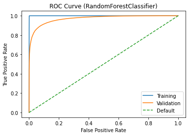

```python
#  train RandomForest model using df_train_processed
#X_train, val_x, Y_train, val_y = split_data(df_train_processed.drop('SeriousDlqin2yrs', axis=1), df_train_processed['SeriousDlqin2yrs'].astype('uint8'))

###################### replace dataset with df_train_created and df_oversampled
# Split the data into training and validation sets using df_train_created
X_train, val_x, Y_train, val_y = split_data(df_oversampled.drop('SeriousDlqin2yrs', axis=1), df_oversampled['SeriousDlqin2yrs'])
##X_train, val_x, Y_train, val_y = split_data(df_train_created.drop('SeriousDlqin2yrs', axis=1), df_train_created['SeriousDlqin2yrs'])
#####################

model_rf = RandomForestClassifier().fit(X_train, Y_train)
Y_pred_rf = model_rf.predict(X_train)

evaluate_model(model_rf,
               X_train, Y_train, val_x, val_y)
```

```python
display_evaluation_metrics(model_rf, val_x, val_y)

##0.82892 public and private score on kaggle
```

```
| Metric           |    Value |
|------------------+----------|
| Accuracy         | 0.909128 |
| Precision        | 0.912043 |
| Recall           | 0.905871 |
| F1-score         | 0.908946 |
| AUC-ROC          | 0.970866 |
| Gini coefficient | 0.941732 |
```

```python
#metrics for random forest
modify_roc_dict(model_rf,
                y_test=val_y,
                X_test=val_x,
                name='RandomForest',
                dict_modify=roc_dict)
modify_prc_dict(clf=model_rf,
                y_test=val_y,
                X_test=val_x,
                name='RandomForest',
                dict_modify=prc_dict)
```

### Logistic Regression

```
Accuracy on training set: 0.759074609964771
ROC AUC score on training set: 0.8331829904262636
Accuracy on validation set: 0.7555289167237499
ROC AUC score on validation set: 0.8283347809858268
```

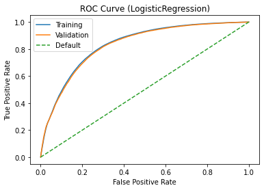

```python
#  train Logistic Regression using df_train_processed
#X_train, val_x, Y_train, val_y = split_data(df_train_processed.drop('SeriousDlqin2yrs', axis=1), df_train_processed['SeriousDlqin2yrs'])

###################### replace dataset with df_train_created and df_oversampled
# Split the data into training and validation sets using df_train_created
X_train, val_x, Y_train, val_y = split_data(df_oversampled.drop('SeriousDlqin2yrs', axis=1), df_oversampled['SeriousDlqin2yrs'])
## X_train, val_x, Y_train, val_y = split_data(df_train_created.drop('SeriousDlqin2yrs', axis=1), df_train_created['SeriousDlqin2yrs'])
#####################

# Initialize and fit the logistic regression model
model_lr = LogisticRegression(max_iter=1000)
model_lr.fit(X_train, Y_train)

# Predict on the training set
Y_pred_lr_train = model_lr.predict(X_train)

evaluate_model(model_lr, X_train, Y_train, val_x, val_y)
```

```python
display_evaluation_metrics(model_lr, val_x, val_y)
```

```
| Metric           |    Value |
|------------------+----------|
| Accuracy         | 0.755529 |
| Precision        | 0.759341 |
| Recall           | 0.749175 |
| F1-score         | 0.754224 |
| AUC-ROC          | 0.828335 |
| Gini coefficient | 0.65667  |
```

```python
#metrics for lr
modify_roc_dict(clf=model_lr,
                y_test=val_y,
                X_test=val_x,
                name='Logistic Regression',
                dict_modify=roc_dict)
modify_prc_dict(clf=model_lr,
                y_test=val_y,
                X_test=val_x,
                name='Logistic Regression',
                dict_modify=prc_dict)
```

### SVC support vector classifier

```python
# using training data with new created cols

# X_train_created, val_x, Y_train_created, val_y = split_data(
#     df_train_created.drop('SeriousDlqin2yrs', axis=1),
#     df_train_created['SeriousDlqin2yrs'],
# )
# df_train_created
```

[output not shown]

```python
from sklearn.preprocessing import StandardScaler

# Select all columns except for target variable column
X_train = df_train_created.drop('SeriousDlqin2yrs', axis=1)

# Initialize scaler object
scaler = StandardScaler()

# Standardize the selected columns
X_train_standardized = scaler.fit_transform(X_train)

# # Create an instance of StandardScaler
# scaler = StandardScaler()

# # Fit the scaler to the processed training data with new created columns
# scaler.fit(X_train_created)

# # Transform the processed training data using the scaler
# X_train_standardized = scaler.transform(X_train_created)

# # Transform the validation data using the scaler
# val_x_standardized = scaler.transform(val_x)

# # Create a DataFrame with the standardized training data
# df_train_standardized = pd.DataFrame(X_train_standardized, columns=X_train_created.columns)
```

```
Accuracy on training set: 0.496321443246522
ROC AUC score on training set: 0.33952780745445527
Accuracy on validation set: 0.49683840482114733
ROC AUC score on validation set: 0.34957447834448097
```

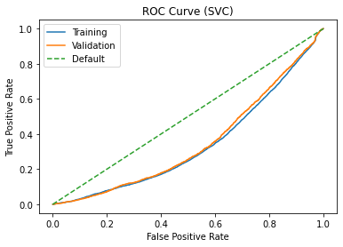

```python
# Split the data into training and validation sets
X_train, val_x, Y_train, val_y = split_data(
    X_train_standardized,
    df_train_processed['SeriousDlqin2yrs'],
)

# Create the SVC model
model_svc = SVC(C=1.0, kernel='rbf',
          gamma='auto',
          probability=True,
          max_iter=400)

# Fit the model on the standardized training data
model_svc.fit(X_train, Y_train)

# Predict on the training set
Y_pred_svc_train = model_svc.predict(X_train)

# Evaluate the model
evaluate_model(model_svc, X_train, Y_train, val_x, val_y)
```

```python
#metrics for svc
modify_roc_dict(model_svc,
                y_test=val_y,
                X_test=val_x,
                name='SVC',
                dict_modify=roc_dict)
modify_prc_dict(clf=model_svc,
                y_test=val_y,
                X_test=val_x,
                name='SVC',
                dict_modify=prc_dict)
```

### KNN

```python
roc_dict.keys()
```

```
dict_keys(['XGBoost', 'RandomForest', 'Logistic Regression', 'SVC'])
```

```python
from sklearn.neighbors import KNeighborsClassifier
```

```
Accuracy on training set: 0.9439704932788072
ROC AUC score on training set: 0.9515029396206143
Accuracy on validation set: 0.9311525555276554
ROC AUC score on validation set: 0.7278189582591197
```

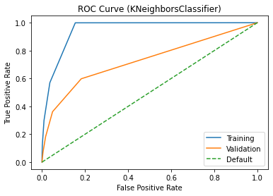

```python
#  train KNN using df_train_processed
X_train, val_x, Y_train, val_y = split_data(X_train_standardized, df_train_processed['SeriousDlqin2yrs'])

###################### replace dataset with df_train_created
# Split the data into training and validation sets using df_train_created
# X_train, val_x, Y_train, val_y = split_data(df_train_created.drop('SeriousDlqin2yrs', axis=1), df_train_created['SeriousDlqin2yrs'])
#####################

###################### replace dataset with df_train_standardized
## Split the data into training and validation sets using df_train_created
## X_train, val_x, Y_train, val_y = split_data(df_train_standardized, Y_train_processed)
#####################

# Initialize and fit the KNN model
knn_model = KNeighborsClassifier(n_neighbors=5, n_jobs=-1)
knn_model.fit(X_train, Y_train)

# Predict on the training set
Y_pred_train = knn_model.predict(X_train)

evaluate_model(knn_model, X_train, Y_train, val_x, val_y)
```

```python
display_evaluation_metrics(knn_model, val_x, val_y)
```

```
| Metric           |    Value |
|------------------+----------|
| Accuracy         | 0.931153 |
| Precision        | 0.432477 |
| Recall           | 0.182965 |
| F1-score         | 0.257143 |
| AUC-ROC          | 0.727819 |
| Gini coefficient | 0.455638 |
```

```python
#metrics for knn
modify_roc_dict(knn_model,
                y_test=val_y,
                X_test=val_x,
                name='KNN',
                dict_modify=roc_dict)
modify_prc_dict(clf=knn_model,
                y_test=val_y,
                X_test=val_x,
                name='knn',
                dict_modify=prc_dict)
```

```python
#see keys we have
roc_dict.keys()
```

```
dict_keys(['XGBoost', 'RandomForest', 'Logistic Regression', 'SVC', 'KNN'])
```

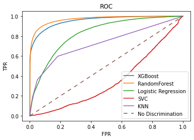

```python
## plot roc curve for all models in one graph
for key in roc_dict:
    clf = roc_dict[key]
    plt.plot(clf['fpr'], clf['tpr'], label=key)
plt.xlabel("FPR")
plt.ylabel("TPR")
plt.title("ROC")
plt.plot([0,1], [0,1], label='No Discrimination', linestyle='-', dashes=(5, 5))
plt.legend()
plt.savefig(os.path.join('roc_curve_all_models.png'))

plt.show()
```

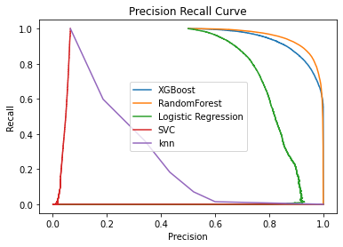

```python
for key in prc_dict:
    clf = prc_dict[key]
    plt.plot(clf['precision'], clf['recall'], label=key)
plt.xlabel("Precision")
plt.ylabel("Recall")
plt.title("Precision Recall Curve")
plt.legend()

plt.savefig(os.path.join('prc_curve_all_models.png'))



plt.show()
```

**So I select xgboost for hyperparameter tunning**

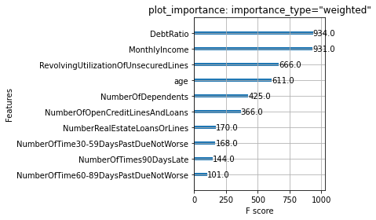

```python
#”weight” is the number of times a feature appears in a tree
xgb.plot_importance(model_xgboost,
                    importance_type='weight',
                    max_num_features=10,
                    title='plot_importance: importance_type="weighted"')
plt.tight_layout()
plt.show()
```

By examining this graph, you can identify the most important features in the XGBoost model based on their weight importance. The higher the weight value, the more frequently the feature is used to split the data and make decisions in the model.

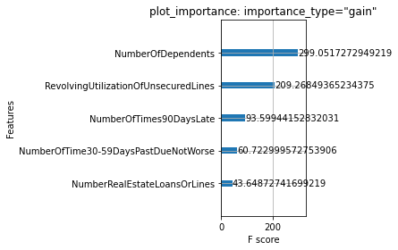

```python
#”gain” is the average gain of splits which use the feature

xgb.plot_importance(model_xgboost,
                    importance_type='gain',
                    max_num_features=5,
                    title='plot_importance: importance_type="gain"')
plt.tight_layout()
plt.show()
```

By examining this graph, you can identify the most important features in the XGBoost model based on their gain importance. The higher the gain value, the more effective the feature is in reducing the loss when splitting the data.

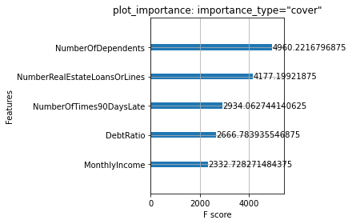

```python
#cover is the average coverage of splits which use the feature
#where coverage is defined as the number of samples affected by the split

xgb.plot_importance(model_xgboost,
                    importance_type='cover',
                    max_num_features=5,
                    title='plot_importance: importance_type="cover"')
plt.tight_layout()
plt.show()
```

By examining this plot, you can identify the most influential features in the XGBoost model based on their cover importance. The higher the cover value, the more frequently the feature is used in the model's decision-making process.

```python
joblib.dump(model_xgboost, 'models/xgb_default_params.pkl')
```

```
['models/xgb_default_params.pkl']
```

```python
df_test_created= pd.read_csv("csv/df_test_created.csv")
```

```python
test_X_created = df_test_created.drop(["SeriousDlqin2yrs"],axis=1)

test_X_created.shape
```

```
(101503, 8)
```

```python
# Predict
test_X = df_test_processed.drop(["SeriousDlqin2yrs"],axis=1)
test_X.shape
```

```
(101503, 10)
```

```python
predict_prob = model_oversampledXGB.predict_proba(test_X)[:, -1]
result = pd.DataFrame({"Id": df_test_id, "Probability": predict_prob})
result["Id"] = result["Id"].astype(int)
result["Probability"] = result["Probability"].astype(float)
```

```python
result.to_csv('model_output/predictions-model_oversampledXGB.csv', index=False)
```